# HR Analytics

**Job Involvement**

```python
df2['JobInvolvement'] = df2['JobInvolvement'].map({1:'Low', 2:'Medium', 3:'High', 4:'Very High'})
```

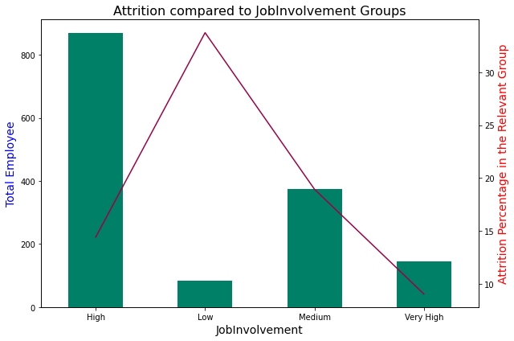

| JobInvolvement | JobInvolvement | Total Employee | Attrition Number | % of Attrition in the Relevant Group | % of Attrition in the Company |
| --- | --- | --- | --- | --- | --- |
| High | High | 868 | 125 | 14.400922 | 52.742616 |
| Low | Low | 83 | 28 | 33.734940 | 11.814346 |
| Medium | Medium | 375 | 71 | 18.933333 | 29.957806 |
| Very High | Very High | 144 | 13 | 9.027778 | 5.485232 |

```python
graph_df(x = 'JobInvolvement')
```

> It is clear from the graph that the more a worker is involved, the is less likely to quit. The percentage in the company is highest for high involvement due to the bigger size group relatively to the remaining groups.

**Job Level**

```python
df2['JobLevel'] = df2['JobLevel'].map({1:'Level-1', 2:'Level-2', 3:'Level-3', 4:'Level-4', 5:'Level-5'})
```

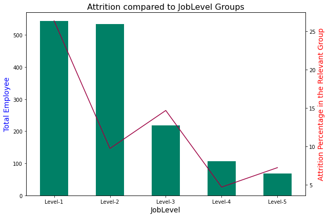

| JobLevel | JobLevel | Total Employee | Attrition Number | % of Attrition in the Relevant Group | % of Attrition in the Company |
| --- | --- | --- | --- | --- | --- |
| Level-1 | Level-1 | 543 | 143 | 26.335175 | 60.337553 |
| Level-2 | Level-2 | 534 | 52 | 9.737828 | 21.940928 |
| Level-3 | Level-3 | 218 | 32 | 14.678899 | 13.502110 |
| Level-4 | Level-4 | 106 | 5 | 4.716981 | 2.109705 |
| Level-5 | Level-5 | 69 | 5 | 7.246377 | 2.109705 |

```python
graph_df(x = 'JobLevel')
```

> The percentage of attrition per group has a decending trend with higher level jobs, even though it jumps back up for mid level jobs. Workers holding a lebel 1 and 3 job are more likely to quit with respective percentage of 26% and 15% in their groups. The remaining groups have much lower attrition rates per groups. Level 1 jobs being the most abundant, the attrition in this group contributes to most of the attrition in the company.

**Job Role**

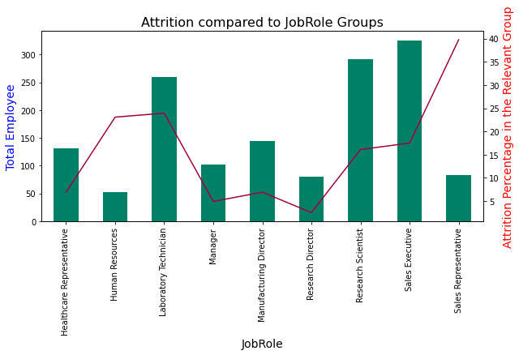

| JobRole | JobRole | Total Employee | Attrition Number | % of Attrition in the Relevant Group | % of Attrition in the Company |
| --- | --- | --- | --- | --- | --- |
| Healthcare Representative | Healthcare Representative | 131 | 9 | 6.870229 | 3.797468 |
| Human Resources | Human Resources | 52 | 12 | 23.076923 | 5.063291 |
| Laboratory Technician | Laboratory Technician | 259 | 62 | 23.938224 | 26.160338 |
| Manager | Manager | 102 | 5 | 4.901961 | 2.109705 |
| Manufacturing Director | Manufacturing Director | 145 | 10 | 6.896552 | 4.219409 |
| Research Director | Research Director | 80 | 2 | 2.500000 | 0.843882 |
| Research Scientist | Research Scientist | 292 | 47 | 16.095890 | 19.831224 |
| Sales Executive | Sales Executive | 326 | 57 | 17.484663 | 24.050633 |
| Sales Representative | Sales Representative | 83 | 33 | 39.759036 | 13.924051 |

```python
graph_df(x = 'JobRole', z=90)
```

> The highest attrition rates per group are in the Sales Representative, Human Resources, and Laboratory Technician jobs. Sales Executive, Laboratory Technician, and Research Scientist contribute to the highest attrition rate of the company due to the highest number oj jobs in these fields.

**Job Satisfaction**

```python
df2['JobSatisfaction'] = df2['JobSatisfaction'].map({1:'Low', 2:'Medium', 3:'High', 4:'Very High'})
```

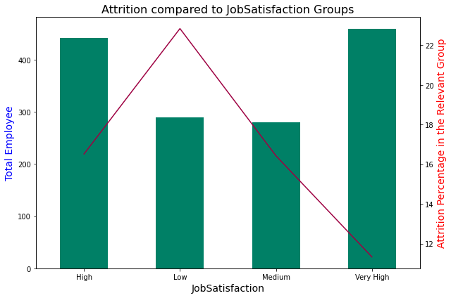

| JobSatisfaction | JobSatisfaction | Total Employee | Attrition Number | % of Attrition in the Relevant Group | % of Attrition in the Company |
| --- | --- | --- | --- | --- | --- |
| High | High | 442 | 73 | 16.515837 | 30.801688 |
| Low | Low | 289 | 66 | 22.837370 | 27.848101 |
| Medium | Medium | 280 | 46 | 16.428571 | 19.409283 |
| Very High | Very High | 459 | 52 | 11.328976 | 21.940928 |

```python
graph_df(x = 'JobSatisfaction')
```

> It is normal that unsatisfied workers will be more likely to quit their jobs. But since they are a minority, they do not contribute to the majority of the company's attrition rate.

**Marital Status**

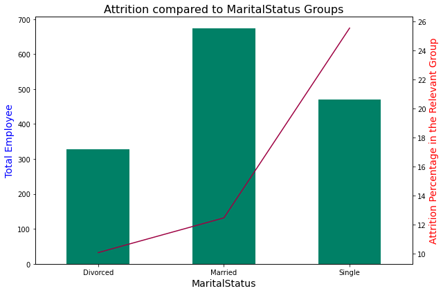

| MaritalStatus | MaritalStatus | Total Employee | Attrition Number | % of Attrition in the Relevant Group | % of Attrition in the Company |
| --- | --- | --- | --- | --- | --- |
| Divorced | Divorced | 327 | 33 | 10.091743 | 13.924051 |
| Married | Married | 673 | 84 | 12.481426 | 35.443038 |
| Single | Single | 470 | 120 | 25.531915 | 50.632911 |

```python
graph_df(x = 'MaritalStatus')
```

> We notice that single people are more likely to quit their job, with a percentage of 25% attrition in this group against 10% roughly in each remaing group. Single workers also contribute to the majority of the attrition in the company with a percentage of 50%. Married and divorced people are less likely to quit perhaps because they have settled in their lives.

**Monthly Income**

```python
bins = [1000, 2000, 3000, 4000, 5000, 7500, 9000, 11000, 15000, 20000]
group_names = ['1000-2000', '2000-3000', '3000-4000', '4000-5000', '5000-7500', '7500-9000', '9000-11000', '11000-15000', '15000-20000']
df2["MonthlyIncome"] = pd.cut(df2["MonthlyIncome"], bins, labels = group_names)
```

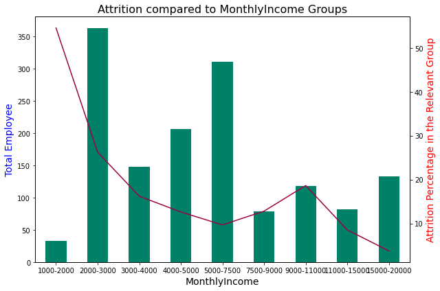

| MonthlyIncome | MonthlyIncome | Total Employee | Attrition Number | % of Attrition in the Relevant Group | % of Attrition in the Company |
| --- | --- | --- | --- | --- | --- |
| 1000-2000 | 1000-2000 | 33 | 18 | 54.545455 | 7.594937 |
| 2000-3000 | 2000-3000 | 362 | 95 | 26.243094 | 40.084388 |
| 3000-4000 | 3000-4000 | 148 | 24 | 16.216216 | 10.126582 |
| 4000-5000 | 4000-5000 | 206 | 26 | 12.621359 | 10.970464 |
| 5000-7500 | 5000-7500 | 310 | 30 | 9.677419 | 12.658228 |
| 7500-9000 | 7500-9000 | 78 | 10 | 12.820513 | 4.219409 |
| 9000-11000 | 9000-11000 | 118 | 22 | 18.644068 | 9.282700 |
| 11000-15000 | 11000-15000 | 82 | 7 | 8.536585 | 2.953586 |
| 15000-20000 | 15000-20000 | 133 | 5 | 3.759398 | 2.109705 |

```python
graph_df(x = "MonthlyIncome")
```

> There is an obvious corelation between monthly income and attrition rate per group: the less a worker earns, the more likely he is to quit his job. A monthly income between $1,000 \ \$ $ and $3,000 \ \$ $ contributes to 47% of the attrition in the company.

**Numbers Companies Worked**

```python
bins = [0, 1, 2, 3, 4, 5, 10]
group_names = ['0', '1', '2', '3', '4', '5+']
df2['NumCompaniesWorked'] = pd.cut(df2['NumCompaniesWorked'], bins, labels = group_names, include_lowest = True, right = False)
```

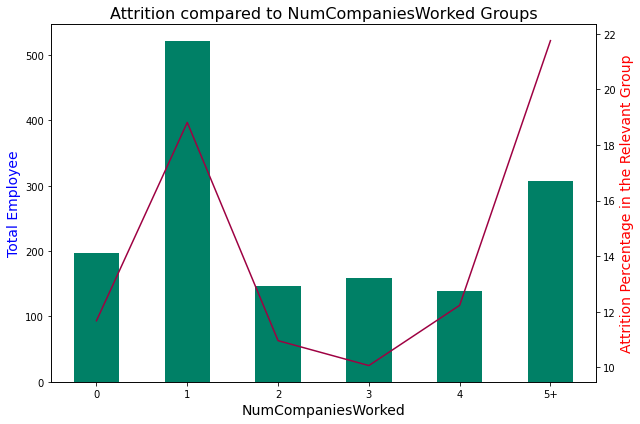

| NumCompaniesWorked | NumCompaniesWorked | Total Employee | Attrition Number | % of Attrition in the Relevant Group | % of Attrition in the Company |
| --- | --- | --- | --- | --- | --- |
| 0 | 0 | 197 | 23 | 11.675127 | 9.704641 |
| 1 | 1 | 521 | 98 | 18.809981 | 41.350211 |
| 2 | 2 | 146 | 16 | 10.958904 | 6.751055 |
| 3 | 3 | 159 | 16 | 10.062893 | 6.751055 |
| 4 | 4 | 139 | 17 | 12.230216 | 7.172996 |
| 5+ | 5+ | 308 | 67 | 21.753247 | 28.270042 |

```python
graph_df(x = 'NumCompaniesWorked')
```

**Over Time**

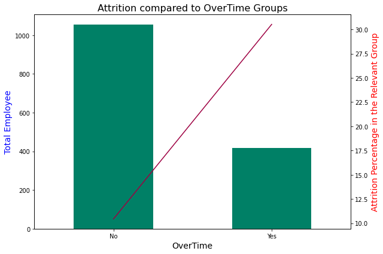

| OverTime | OverTime | Total Employee | Attrition Number | % of Attrition in the Relevant Group | % of Attrition in the Company |
| --- | --- | --- | --- | --- | --- |
| No | No | 1054 | 110 | 10.436433 | 46.413502 |
| Yes | Yes | 416 | 127 | 30.528846 | 53.586498 |

```python
graph_df(x = 'OverTime')
```

> It is evident that workers who over work are going to be more likely to quit their jobs with a percentage of 30% in that group against 10% in the remaing group. Because the non overworked workers outnumber the overworked numbers, both groups contribute equally on the company's attrition rate.

**Percent Salary Hike**

```python
bins = [10, 14, 18, 22, 25]
group_names = ['11-14', '15-18', '19-22', '23-25']
df2['PercentSalaryHike'] = pd.cut(df2['PercentSalaryHike'], bins, labels = group_names)
```

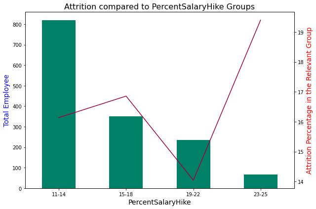

| PercentSalaryHike | PercentSalaryHike | Total Employee | Attrition Number | % of Attrition in the Relevant Group | % of Attrition in the Company |
| --- | --- | --- | --- | --- | --- |
| 11-14 | 11-14 | 818 | 132 | 16.136919 | 55.696203 |
| 15-18 | 15-18 | 350 | 59 | 16.857143 | 24.894515 |
| 19-22 | 19-22 | 235 | 33 | 14.042553 | 13.924051 |
| 23-25 | 23-25 | 67 | 13 | 19.402985 | 5.485232 |

```python
graph_df(x = 'PercentSalaryHike')
```

> The results are not very conclusive, even though we see a small fluction of percentage of attriton in each group. Looking at the result, a worker with highest salary hike is more likely to quit his job. But looking at the total attrtion rate in the company, 55% of them are from the group with lowest salary hike beacause they outnumber the remaing groups, and so for the rest.

**Performance Rating**

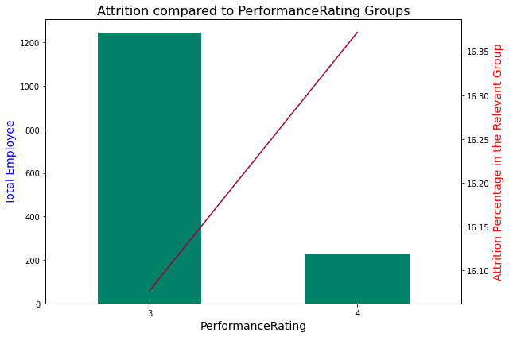

| PerformanceRating | PerformanceRating | Total Employee | Attrition Number | % of Attrition in the Relevant Group | % of Attrition in the Company |
| --- | --- | --- | --- | --- | --- |
| 3 | 3 | 1244 | 200 | 16.077170 | 84.388186 |
| 4 | 4 | 226 | 37 | 16.371681 | 15.611814 |

```python
graph_df(x = 'PerformanceRating')
```

**Relationship Satisfaction**

```python
df2['RelationshipSatisfaction'] = df2['RelationshipSatisfaction'].map({1:'Low', 2:'Medium', 3:'High', 4:'Very High'})
```

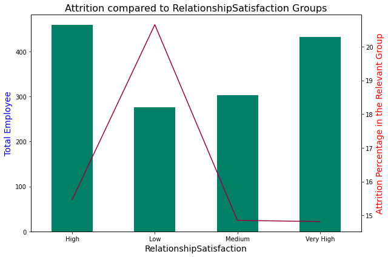

| RelationshipSatisfaction | RelationshipSatisfaction | Total Employee | Attrition Number | % of Attrition in the Relevant Group | % of Attrition in the Company |
| --- | --- | --- | --- | --- | --- |
| High | High | 459 | 71 | 15.468410 | 29.957806 |
| Low | Low | 276 | 57 | 20.652174 | 24.050633 |
| Medium | Medium | 303 | 45 | 14.851485 | 18.987342 |
| Very High | Very High | 432 | 64 | 14.814815 | 27.004219 |

```python
graph_df(x = 'RelationshipSatisfaction')
```

Low relationship satifaction workers are slighlty more likely to quit their jobs with a percentage of 20% in this group against 15% in each remaining group. The contribution towards the total attrition in the company is related to size of each group.

**Stock Option Level**

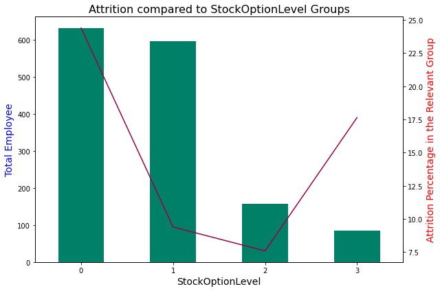

| StockOptionLevel | StockOptionLevel | Total Employee | Attrition Number | % of Attrition in the Relevant Group | % of Attrition in the Company |
| --- | --- | --- | --- | --- | --- |
| 0 | 0 | 631 | 154 | 24.405705 | 64.978903 |
| 1 | 1 | 596 | 56 | 9.395973 | 23.628692 |
| 2 | 2 | 158 | 12 | 7.594937 | 5.063291 |
| 3 | 3 | 85 | 15 | 17.647059 | 6.329114 |

```python
graph_df(x = 'StockOptionLevel')
```

> It seems logical that the lower the stock option level is, the more likely a worker is to quit his job. But the result contradicts this assumption as a worker with the highest stock option level is the second most likelty to quit his job amoung all groups. When looking at total contributions, the lower the stock level option, the higher attrtion rate in the company.

**Total Working Years**

```python
bins = [0, 1, 5, 10, 15, 20, 40]
group_names = ['1', '2-5', '6-10', '11-15', '16-20', '20+']
df2['TotalWorkingYears'] = pd.cut(df2['TotalWorkingYears'], bins, labels = group_names, include_lowest = True)
```

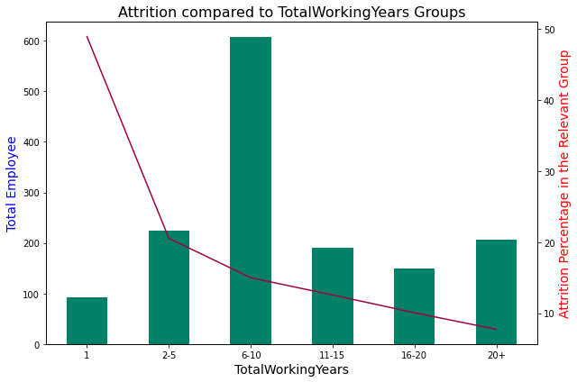

| TotalWorkingYears | TotalWorkingYears | Total Employee | Attrition Number | % of Attrition in the Relevant Group | % of Attrition in the Company |
| --- | --- | --- | --- | --- | --- |
| 1 | 1 | 92 | 45 | 48.913043 | 18.987342 |
| 2-5 | 2-5 | 224 | 46 | 20.535714 | 19.409283 |
| 6-10 | 6-10 | 607 | 91 | 14.991763 | 38.396624 |
| 11-15 | 11-15 | 191 | 24 | 12.565445 | 10.126582 |
| 16-20 | 16-20 | 149 | 15 | 10.067114 | 6.329114 |
| 20+ | 20+ | 207 | 16 | 7.729469 | 6.751055 |

```python
graph_df(x = 'TotalWorkingYears')
```

> The lower the number of total working years, the more likely a worker is to quit his job. The group with 6 to 10 years of total working is the one that contributes the most to the attrition of the company since it contains the highest number of workers.

**Training Times Last Year**

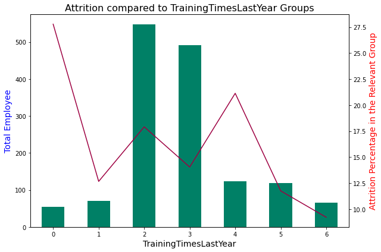

| TrainingTimesLastYear | TrainingTimesLastYear | Total Employee | Attrition Number | % of Attrition in the Relevant Group | % of Attrition in the Company |
| --- | --- | --- | --- | --- | --- |
| 0 | 0 | 54 | 15 | 27.777778 | 6.329114 |
| 1 | 1 | 71 | 9 | 12.676056 | 3.797468 |
| 2 | 2 | 547 | 98 | 17.915905 | 41.350211 |
| 3 | 3 | 491 | 69 | 14.052953 | 29.113924 |
| 4 | 4 | 123 | 26 | 21.138211 | 10.970464 |
| 5 | 5 | 119 | 14 | 11.764706 | 5.907173 |
| 6 | 6 | 65 | 6 | 9.230769 | 2.531646 |

```python
graph_df(x = 'TrainingTimesLastYear')
```

> We see that the precentage of attrition in groups flucuates in a non montonous way with training times. We note that least training times have the highest attrition percentage in this group while highest training time have the smnallest attrition percentage in this group. The percentage of attrtition in the company is affected by each group size.

**Work Life Balance**

```python
df2['WorkLifeBalance'] = df2['WorkLifeBalance'].map({1:'Bad', 2:'Good', 3:'Better', 4:'Best'})
```

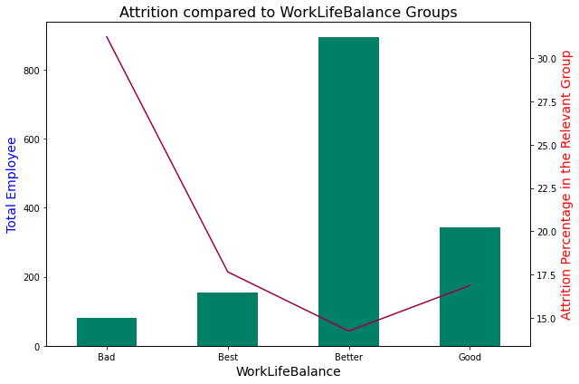

| WorkLifeBalance | WorkLifeBalance | Total Employee | Attrition Number | % of Attrition in the Relevant Group | % of Attrition in the Company |
| --- | --- | --- | --- | --- | --- |
| Bad | Bad | 80 | 25 | 31.250000 | 10.548523 |
| Best | Best | 153 | 27 | 17.647059 | 11.392405 |
| Better | Better | 893 | 127 | 14.221725 | 53.586498 |
| Good | Good | 344 | 58 | 16.860465 | 24.472574 |

```python
graph_df(x = 'WorkLifeBalance')
```

**Years at Company**

```python
bins = [0, 1, 5, 10, 40]
group_names = ['1', '2-5', '6-10', '10+']
df2['YearsAtCompany'] = pd.cut(df2['YearsAtCompany'], bins, labels = group_names, include_lowest = True)
```

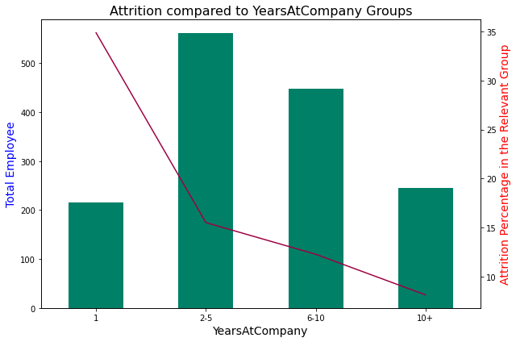

| YearsAtCompany | YearsAtCompany | Total Employee | Attrition Number | % of Attrition in the Relevant Group | % of Attrition in the Company |
| --- | --- | --- | --- | --- | --- |
| 1 | 1 | 215 | 75 | 34.883721 | 31.645570 |
| 2-5 | 2-5 | 561 | 87 | 15.508021 | 36.708861 |
| 6-10 | 6-10 | 448 | 55 | 12.276786 | 23.206751 |
| 10+ | 10+ | 246 | 20 | 8.130081 | 8.438819 |

```python
graph_df(x = 'YearsAtCompany')
```

> Workers that have worked longer in the company are less likely to leave their job. Workers that have worked 1 year are less have a 35% attrition percentage which is much higher then the next highest percentage which is 15% and corresponds to the group of workers that have worked between 2 to 5 years at the company. Attrition percentage in the company remain relative also to each group size.

**Years in Current Role**

```python
bins = [0, 1, 4, 6, 7, 10, 18]
group_names = ['1', '2-4', '5-6', '7', '8-10', '10+']
df2['YearsInCurrentRole'] = pd.cut(df2['YearsInCurrentRole'], bins, labels = group_names, include_lowest = True)
```

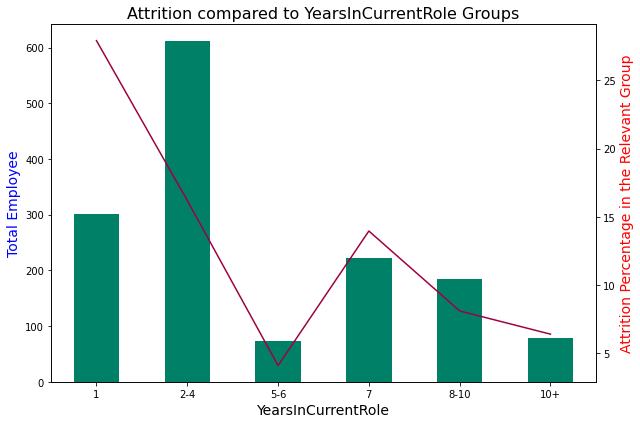

| YearsInCurrentRole | YearsInCurrentRole | Total Employee | Attrition Number | % of Attrition in the Relevant Group | % of Attrition in the Company |
| --- | --- | --- | --- | --- | --- |
| 1 | 1 | 301 | 84 | 27.906977 | 35.443038 |
| 2-4 | 2-4 | 611 | 99 | 16.202946 | 41.772152 |
| 5-6 | 5-6 | 73 | 3 | 4.109589 | 1.265823 |
| 7 | 7 | 222 | 31 | 13.963964 | 13.080169 |
| 8-10 | 8-10 | 185 | 15 | 8.108108 | 6.329114 |
| 10+ | 10+ | 78 | 5 | 6.410256 | 2.109705 |

```python
graph_df(x = 'YearsInCurrentRole')
```

> Genrally, the attrition percentage has a decreasing trend when the number of years in a current role increase, even though we observe a small jump in a middlw group. A worker that has been for a year or less in a current role is the most likely to quit his job with an attrition percentage of 28%. The next biggest percentage corresponds to the next group, workers in a crurrent role for 2 to 4 years, with an attrition percentage of 16%. Together, these groups contribute to 77% of the attrition in the company, knowing also that they contain most of the workers.

**Years Since Last Promotion**

```python
bins = [0, 1, 2, 3, 4, 7, 8, 16]
group_names = ['0', '1', '2', '3', '4-6', '7', '8+']
df2['YearsSinceLastPromotion'] = pd.cut(df2['YearsSinceLastPromotion'], bins, labels = group_names, include_lowest = True, right = False)
```

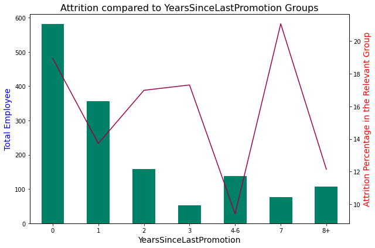

| YearsSinceLastPromotion | YearsSinceLastPromotion | Total Employee | Attrition Number | % of Attrition in the Relevant Group | % of Attrition in the Company |
| --- | --- | --- | --- | --- | --- |
| 0 | 0 | 581 | 110 | 18.932874 | 46.413502 |
| 1 | 1 | 357 | 49 | 13.725490 | 20.675105 |
| 2 | 2 | 159 | 27 | 16.981132 | 11.392405 |
| 3 | 3 | 52 | 9 | 17.307692 | 3.797468 |
| 4-6 | 4-6 | 138 | 13 | 9.420290 | 5.485232 |
| 7 | 7 | 76 | 16 | 21.052632 | 6.751055 |
| 8+ | 8+ | 107 | 13 | 12.149533 | 5.485232 |

```python
graph_df(x = 'YearsSinceLastPromotion')
```

> The results are very unstable, and we can't view a direct link between years since last promotion and attrition percentage. We see that the highest attrition percentage corresponds to the 7 years since last promotion group. The highest attrition rates in the company correspond to 0 and 1 year since last promotion as they assemble most of the company's workers.

**Years with Current Manager**

```python
bins = [0, 1, 2, 3, 4, 5, 6, 7, 8, 9, 10, 18]
group_names = ['0', '1', '2', '3', '4', '5', '6', '7', '8', '9', '10+']
df2['YearsWithCurrManager'] = pd.cut(df2['YearsWithCurrManager'], bins, labels = group_names, include_lowest = True, right = False)
```

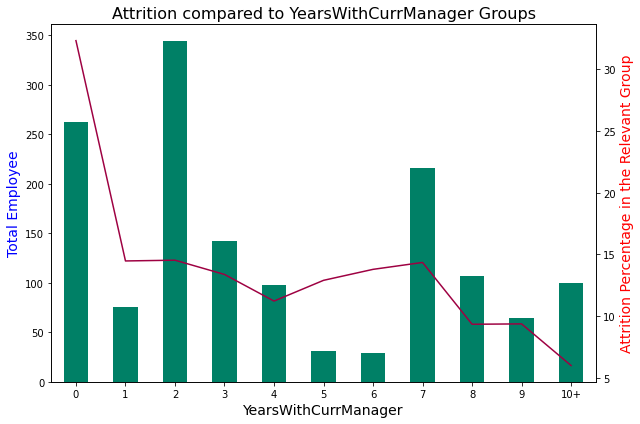

| YearsWithCurrManager | YearsWithCurrManager | Total Employee | Attrition Number | % of Attrition in the Relevant Group | % of Attrition in the Company |
| --- | --- | --- | --- | --- | --- |
| 0 | 0 | 263 | 85 | 32.319392 | 35.864979 |
| 1 | 1 | 76 | 11 | 14.473684 | 4.641350 |
| 2 | 2 | 344 | 50 | 14.534884 | 21.097046 |
| 3 | 3 | 142 | 19 | 13.380282 | 8.016878 |
| 4 | 4 | 98 | 11 | 11.224490 | 4.641350 |
| 5 | 5 | 31 | 4 | 12.903226 | 1.687764 |
| 6 | 6 | 29 | 4 | 13.793103 | 1.687764 |
| 7 | 7 | 216 | 31 | 14.351852 | 13.080169 |
| 8 | 8 | 107 | 10 | 9.345794 | 4.219409 |
| 9 | 9 | 64 | 6 | 9.375000 | 2.531646 |
| 10+ | 10+ | 100 | 6 | 6.000000 | 2.531646 |

```python
graph_df(x = 'YearsWithCurrManager')
```

> We see that the number of years spent with the same manager has an impact on the attrition rate. The longer a worker is with a manager, the less likely he is to quit his job. We observe the highest attrition rate for 0 years with cuurent manager, with a percentage of 32%. This group also contributes the most to the company's percentage of attrtion.

### Wage Gap? (Knowledge Nugget)

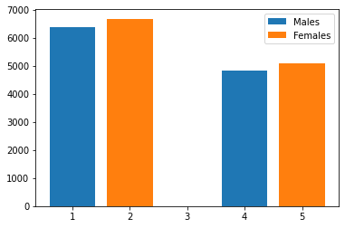

```python
plt.plot()
mean_m = np.mean(df.MonthlyIncome[df.Gender == 'Male'])
med_m = np.median(df.MonthlyIncome[df.Gender == 'Male'])
plt.bar([1,4],[mean_m, med_m])
mean_f = np.mean(df.MonthlyIncome[df.Gender == 'Female'])
med_f = np.median(df.MonthlyIncome[df.Gender == 'Female'])
plt.bar([2,5],[mean_f, med_f])
plt.legend(['Males','Females'])
```

## Data Preprocessing

```python
df['Attrition'] = df['Attrition'].map({'Yes': 1, 'No': 0}) # 'Yes'/'No' to 1/0
df.Attrition.value_counts() # UNBALENCED DATA SET
```

```
0    1233
1     237
Name: Attrition, dtype: int64
```

```python
from sklearn.preprocessing import LabelEncoder
le = LabelEncoder()
for col in df:
    if df[col].dtype == object:
        df[col] = le.fit_transform(df[col])
        print('{}: {}\n'.format(col,dict(zip(le.classes_, le.transform(le.classes_)))))
```

```
BusinessTravel: {'Non-Travel': 0, 'Travel_Frequently': 1, 'Travel_Rarely': 2}

Department: {'Human Resources': 0, 'Research & Development': 1, 'Sales': 2}

EducationField: {'Human Resources': 0, 'Life Sciences': 1, 'Marketing': 2, 'Medical': 3, 'Other': 4, 'Technical Degree': 5}

Gender: {'Female': 0, 'Male': 1}

JobRole: {'Healthcare Representative': 0, 'Human Resources': 1, 'Laboratory Technician': 2, 'Manager': 3, 'Manufacturing Director': 4, 'Research Director': 5, 'Research Scientist': 6, 'Sales Executive': 7, 'Sales Representative': 8}

MaritalStatus: {'Divorced': 0, 'Married': 1, 'Single': 2}

OverTime: {'No': 0, 'Yes': 1}
```

### Correlation Heatmap

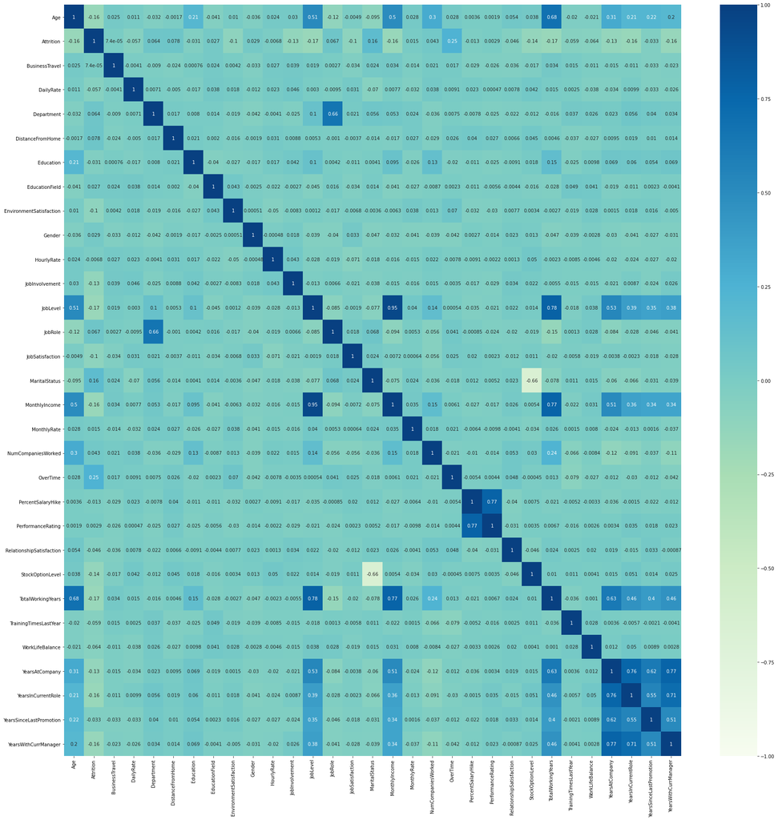

```python
plt.figure(figsize=(30, 30))
sns.heatmap(df.corr(), annot=True, vmin=-1.0, vmax=1.0, cmap='GnBu')
```

```python
y = df.Attrition
X = df.drop(columns=['Attrition'])

# Split dataset into training and testing data
from sklearn.model_selection import train_test_split
X_train, X_test, y_train, y_test = train_test_split(X, y, test_size=0.25, random_state=21)
```

## Scoring Function

```python
from sklearn.metrics import accuracy_score, classification_report, confusion_matrix

def print_score(clf, X_train, y_train, X_test, y_test, train=True):

    if train:
        pred = clf.predict(X_train)
        print("Training Result:\n")
        print("Accuracy: {0:.4f}\n".format(accuracy_score(y_train, pred)))
        print("Confusion Matrix: \n {}".format(confusion_matrix(y_train, pred)))

    else:
        pred = clf.predict(X_test)
        print("Testing Result:\n")
        print("Accuracy score: {0:.4f}\n".format(accuracy_score(y_test, pred)))
        print("Confusion Matrix: \n {}".format(confusion_matrix(y_test, pred)))
```

## Naive Decision Tree

```python
from sklearn.tree import DecisionTreeClassifier
naive_tree = DecisionTreeClassifier(random_state=5)
naive_tree.fit(X_train, y_train)
```

```
DecisionTreeClassifier(ccp_alpha=0.0, class_weight=None, criterion='gini',
                       max_depth=None, max_features=None, max_leaf_nodes=None,
                       min_impurity_decrease=0.0, min_impurity_split=None,
                       min_samples_leaf=1, min_samples_split=2,
                       min_weight_fraction_leaf=0.0, presort='deprecated',
                       random_state=5, splitter='best')
```

```python
print_score(naive_tree, X_train, y_train, X_test, y_test, train=True)
```

```
Training Result:

Accuracy: 1.0000

Confusion Matrix:
 [[922   0]
 [  0 180]]
```

```python
print_score(naive_tree, X_train, y_train, X_test, y_test, train=False)
```

```
Testing Result:

Accuracy score: 0.8043

Confusion Matrix:
 [[273  38]
 [ 34  23]]
```

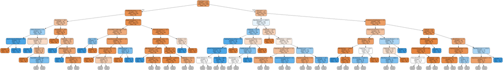

```python
# Visulization
# NOTE: I did not write this block of code.
#       It's adapted from what I found online.

from sklearn import tree
from IPython.display import Image as PImage
from subprocess import check_call
from PIL import Image, ImageDraw

y_pred = naive_tree.predict(X_test)

with open("tree.dot", 'w') as f:
     f = tree.export_graphviz(naive_tree,
                              out_file=f,
                              max_depth = 6,
                              impurity = False,
                              feature_names = X_test.columns.values,
                              class_names = ['No', 'Yes'],
                              rounded = True,
                              filled= True )

check_call(['dot','-Tpng','tree.dot','-o','tree.png'])

img = Image.open("tree.png")
draw = ImageDraw.Draw(img)
img.save('sample-out.png')
PImage("sample-out.png", height=200, width=1900)
```

## Bagging

```python
from sklearn.ensemble import BaggingClassifier
bag = BaggingClassifier(base_estimator=naive_tree, n_estimators=1000, random_state=21)
bag.fit(X_train, y_train)
```

```
BaggingClassifier(base_estimator=DecisionTreeClassifier(ccp_alpha=0.0,
                                                        class_weight=None,
                                                        criterion='gini',
                                                        max_depth=None,
                                                        max_features=None,
                                                        max_leaf_nodes=None,
                                                        min_impurity_decrease=0.0,
                                                        min_impurity_split=None,
                                                        min_samples_leaf=1,
                                                        min_samples_split=2,
                                                        min_weight_fraction_leaf=0.0,
                                                        presort='deprecated',
                                                        random_state=5,
                                                        splitter='best'),
                  bootstrap=True, bootstrap_features=False, max_features=1.0,
                  max_samples=1.0, n_estimators=1000, n_jobs=None,
                  oob_score=False, random_state=21, verbose=0,
                  warm_start=False)
```

```python
print_score(bag, X_train, y_train, X_test, y_test, train=True)
```

```
Training Result:

Accuracy: 1.0000

Confusion Matrix:
 [[922   0]
 [  0 180]]
```

```python
print_score(bag, X_train, y_train, X_test, y_test, train=False)
```

```
Testing Result:

Accuracy score: 0.8723

Confusion Matrix:
 [[306   5]
 [ 42  15]]
```

## Random Forest

```python
from sklearn.ensemble import RandomForestClassifier
rf = RandomForestClassifier(n_estimators=1000,class_weight={0:1,1:5})
rf.fit(X_train, y_train)
```

```
RandomForestClassifier(bootstrap=True, ccp_alpha=0.0, class_weight={0: 1, 1: 5},
                       criterion='gini', max_depth=None, max_features='auto',
                       max_leaf_nodes=None, max_samples=None,
                       min_impurity_decrease=0.0, min_impurity_split=None,
                       min_samples_leaf=1, min_samples_split=2,
                       min_weight_fraction_leaf=0.0, n_estimators=1000,
                       n_jobs=None, oob_score=False, random_state=None,
                       verbose=0, warm_start=False)
```

```python
print_score(rf, X_train, y_train, X_test, y_test, train=True)
```

```
Training Result:

Accuracy: 1.0000

Confusion Matrix:
 [[922   0]
 [  0 180]]
```

```python
print_score(rf, X_train, y_train, X_test, y_test, train=False)
```

```
Testing Result:

Accuracy score: 0.8614

Confusion Matrix:
 [[310   1]
 [ 50   7]]
```

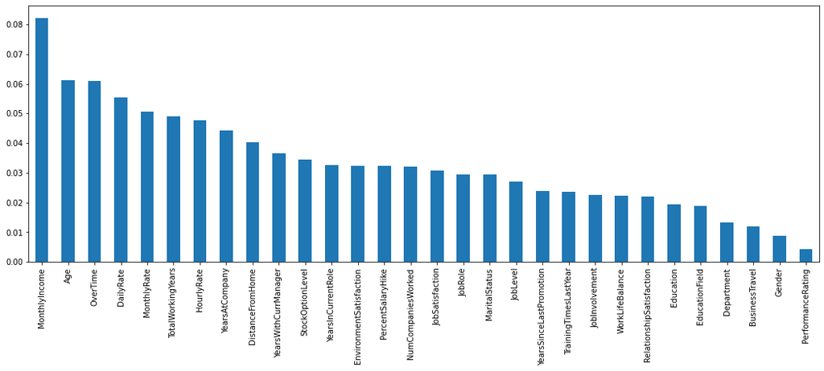

```python
feature_importances = pd.Series(rf.feature_importances_, index=X.columns)
feature_importances.sort_values(ascending=False).plot(kind='bar', figsize=(18,6));
```

## Boosting

```python
from sklearn.ensemble import GradientBoostingClassifier
gb = GradientBoostingClassifier(n_estimators=1000, learning_rate=0.01)
gb.fit(X_train, y_train)
```

```
GradientBoostingClassifier(ccp_alpha=0.0, criterion='friedman_mse', init=None,
                           learning_rate=0.01, loss='deviance', max_depth=3,
                           max_features=None, max_leaf_nodes=None,
                           min_impurity_decrease=0.0, min_impurity_split=None,
                           min_samples_leaf=1, min_samples_split=2,
                           min_weight_fraction_leaf=0.0, n_estimators=1000,
                           n_iter_no_change=None, presort='deprecated',
                           random_state=None, subsample=1.0, tol=0.0001,
                           validation_fraction=0.1, verbose=0,
                           warm_start=False)
```

```python
print_score(gb, X_train, y_train, X_test, y_test, train=True)
```

```
Training Result:

Accuracy: 0.9528

Confusion Matrix:
 [[921   1]
 [ 51 129]]
```

```python
print_score(gb, X_train, y_train, X_test, y_test, train=False)
```

```
Testing Result:

Accuracy score: 0.8750

Confusion Matrix:
 [[302   9]
 [ 37  20]]
```

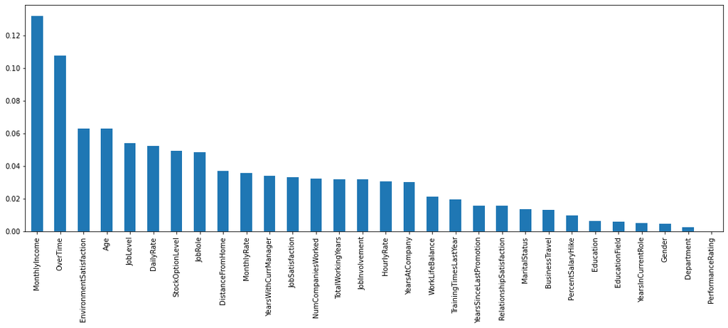

```python
feature_importances = pd.Series(gb.feature_importances_, index=X.columns)
feature_importances.sort_values(ascending=False).plot(kind='bar', figsize=(18,6));
```